# Could you have survived the Titanic?!!

We all know about the luxurious streamline - RMS Titanic which killed around 1500 passengers during its maiden trip to New York! After a lot of research, its believed that once lauded as state-of-art design, had many flaws. In other words, unfortunately, it was bound to be doomed!

With the dataset from Kaggle, I want to explore the chances of surviving this disaster!

Some of my research questions are: How many passengers survived? Did the class of passenger matter? If yes, What proportion of lower class passengers survived the disaster? What was the proportion of females and males travelling? Did women and children have more chances of survival than the others?

```python
%pylab inline
import pandas as pd
import numpy as np
import matplotlib.pyplot as plt
import seaborn as sns

titanic = pd.read_csv('C:/Users/Kousalya/Downloads/titanic-data.csv')
titanic.head()
```

|  | PassengerId | Survived | Pclass | Name | Sex | Age | SibSp | Parch | Ticket | Fare | Cabin | Embarked |
| --- | --- | --- | --- | --- | --- | --- | --- | --- | --- | --- | --- | --- |
| 0 | 1 | 0 | 3 | Braund, Mr. Owen Harris | male | 22.0 | 1 | 0 | A/5 21171 | 7.2500 | NaN | S |
| 1 | 2 | 1 | 1 | Cumings, Mrs. John Bradley (Florence Briggs Th... | female | 38.0 | 1 | 0 | PC 17599 | 71.2833 | C85 | C |
| 2 | 3 | 1 | 3 | Heikkinen, Miss. Laina | female | 26.0 | 0 | 0 | STON/O2. 3101282 | 7.9250 | NaN | S |
| 3 | 4 | 1 | 1 | Futrelle, Mrs. Jacques Heath (Lily May Peel) | female | 35.0 | 1 | 0 | 113803 | 53.1000 | C123 | S |
| 4 | 5 | 0 | 3 | Allen, Mr. William Henry | male | 35.0 | 0 | 0 | 373450 | 8.0500 | NaN | S |

```python
titanic.info()
```

```
<class 'pandas.core.frame.DataFrame'>
RangeIndex: 891 entries, 0 to 890
Data columns (total 12 columns):
PassengerId    891 non-null int64
Survived       891 non-null int64
Pclass         891 non-null int64
Name           891 non-null object
Sex            891 non-null object
Age            714 non-null float64
SibSp          891 non-null int64
Parch          891 non-null int64
Ticket         891 non-null object
Fare           891 non-null float64
Cabin          204 non-null object
Embarked       889 non-null object
dtypes: float64(2), int64(5), object(5)
memory usage: 83.6+ KB
```

```python
#Checking for missing values

titanic.apply(lambda x: sum(x.isnull()),axis=0)
```

```
PassengerId      0
Survived         0
Pclass           0
Name             0
Sex              0
Age            177
SibSp            0
Parch            0
Ticket           0
Fare             0
Cabin          687
Embarked         2
dtype: int64
```

Age, Cabin and Embarked have the missing values. Majorly, 20% of Age values are missing and 77% of Cabin values are missing. We can replace the missing values in Age variable using the median value and the Embarked column with the the most_frequent value.

### Imputing missing values in Age and Embarked columns

#### Age column

```python
titanic['Age'].fillna(titanic['Age'].median(), inplace=True)
```

#### Embarked column

```python
titanic = titanic.fillna(titanic['Embarked'].value_counts().index[0])
```

## Distribution of Passengers by Cabin

```python
#For the non-numerical values we can look at frequency distribution to understand whether they make sense or not.
titanic['Cabin'].head()
```

```
0       S
1     C85
2       S
3    C123
4       S
Name: Cabin, dtype: object
```

```python
titanic['Cabin'] = titanic['Cabin'].astype(str)
```

Now since the cabin column with the seat numbers doesn't seem important. But, lets try to extract just the cabin levels from each. For that, I'm trying to first convert the data column to string and then parse just the first element.

```python
import re
def getCoachNames(onboarder):
    """This function extracts the deck names from the cabin column"""
    coaches = onboarder
    regex = re.compile('[^a-zA-Z]')
    return regex.sub('', coaches[0])

titanic['CabinNames'] = titanic[['Cabin']].apply(getCoachNames, axis = 1)
titanic.CabinNames.unique()
```

```
array(['S', 'C', 'E', 'G', 'D', 'A', 'CCC', 'B', 'F', 'FG', 'DD', 'BB',
       'FE', 'CC', 'BBBB', 'T', 'BBB'], dtype=object)
```

Looking at the different deck levels, deck- T was called the Boat Deck. It was specifically for a passenger named Mr. Blackwell Stephen Weart and there was no evidence that anyone occupied this deck. Hence, for my analysis I'll be dropping this value. Also, I'm getting strings like 'BBB' or 'CCCC' since in the data set there are series of seat numbers given for that row. Maybe a single member booked for 2-3 family members under his/her name.

```python
titanic = titanic[titanic['CabinNames'] != 'T']
```

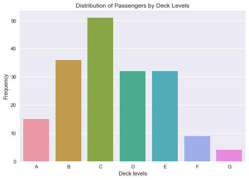

```python
cplt = sns.countplot(x = 'CabinNames', order = ['A','B','C','D','E','F','G'], data = titanic)
cplt.set_title('Distribution of Passengers by Deck Levels')
cplt.set(xlabel='Deck levels', ylabel='Frequency')
```

Looking at the distribution, looks like cabin C had majority of the passengers and then cabin B.

## What was the proportion of females and males travelling?

```python
titanic['Sex'].value_counts()
```

```
male      576
female    314
Name: Sex, dtype: int64
```

Out of 891, 65% of them are males and rest 35% are females.

## How many children were on-board?

```python
def isChild(onboarder):
    """This function uses the condition 'Age < 21' to divide the data further into Male/Female/Child"""
    Age, sex = onboarder
    if Age < 21:
        return 'child'
    else:
        return sex

titanic['status'] = titanic[['Age','Sex']].apply(isChild, axis = 1)
```

```python
titanic['status'].value_counts()
```

```
male      473
female    237
child     180
Name: status, dtype: int64
```

It looks like there were 180 children on the ship! That means, 53% are males, 26.5% are females and 20% are children.

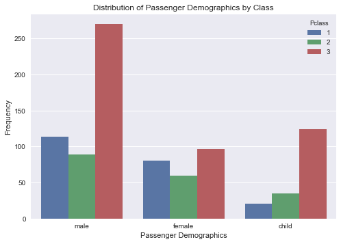

```python
plt = sns.countplot(x = 'status', hue='Pclass',data = titanic)
plt.set_title('Distribution of Passenger Demographics by Class')
plt.set(xlabel = 'Passenger Demographics', ylabel='Frequency')
```

Seeing the distribution of people across the different classes, we see that majority of the passengers were in the lower class.

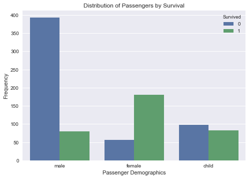

```python
plt = sns.countplot(x = 'status', hue='Survived',data = titanic)
plt.set_title('Distribution of Passengers by Survival')
plt.set(xlabel = 'Passenger Demographics', ylabel='Frequency')
```

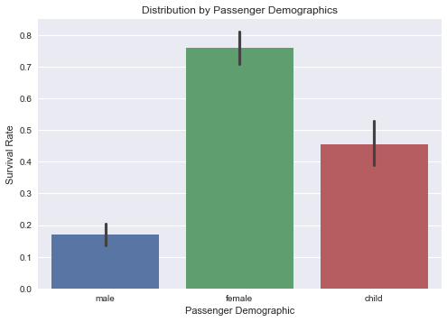

```python
statPlot = sns.barplot(data=titanic, x='status', y='Survived')
statPlot.set(xlabel='Passenger Demographic', ylabel='Survival Rate')
statPlot.set_title('Distribution by Passenger Demographics')
```

```python
titanic_males = titanic[titanic.status == 'male']
titanic_females = titanic[titanic.status == 'female']
titanic_children = titanic[titanic.status == 'child']
```

```python
titanic_males.Survived.mean()
```

```
0.16913319238900634
```

```python
titanic_females.Survived.mean()
```

```
0.759493670886076
```

```python
titanic_children.Survived.mean()
```

```
0.45555555555555555
```

## Did the class of passenger matter?

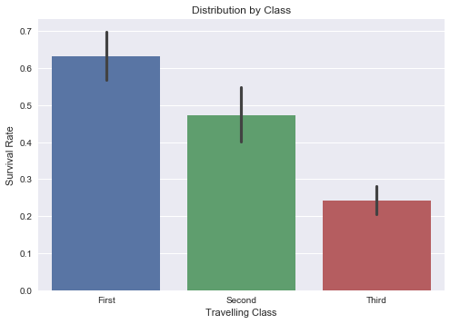

```python
cPlt = sns.barplot(data=titanic, x='Pclass', y='Survived')
cPlt.set_title('Distribution by Class')
cPlt.set(xlabel='Travelling Class', ylabel='Survival Rate')
cPlt.set(xticklabels=['First','Second','Third'])
```

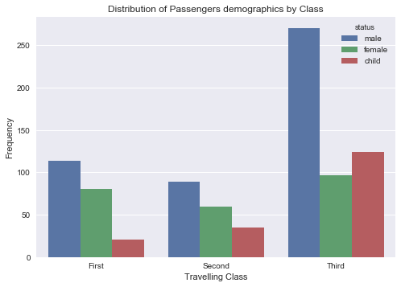

```python
cPlt = sns.countplot(x = 'Pclass', hue='status',data = titanic)
cPlt.set_title('Distribution of Passengers demographics by Class')
cPlt.set(xlabel='Travelling Class', ylabel='Frequency')
cPlt.set(xticklabels=['First','Second','Third'])
```

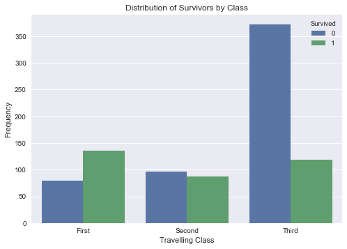

```python
cPlt = sns.countplot(x = 'Pclass', hue='Survived',data = titanic)
cPlt.set_title('Distribution of Survivors by Class')
cPlt.set(xlabel='Travelling Class', ylabel='Frequency')
cPlt.set(xticklabels=['First','Second','Third'])
```

```python
upperClass_psgrs = titanic[titanic.Pclass == 1]
middleClass_psgrs = titanic[titanic.Pclass == 2]
lowerClass_psgrs = titanic[titanic.Pclass == 3]
```

```python
upperClass_psgrs.Survived.mean()
```

```
0.6325581395348837
```

```python
middleClass_psgrs.Survived.mean()
```

```
0.47282608695652173
```

```python
lowerClass_psgrs.Survived.mean()
```

```
0.24236252545824846
```

We can say that there is some relation between the survival rate and the class in which the passenger was travelling! Looks like the first class passengers have higher chances compared to the other classes. First class passengers have a survival rate of 63%, middle class has 48% and lower class has around 24% Hence, the survival rate of first class passengers is almost three times higher than the survival rate of a passenger travelling in third class cabin!

## Did age effect survivability?

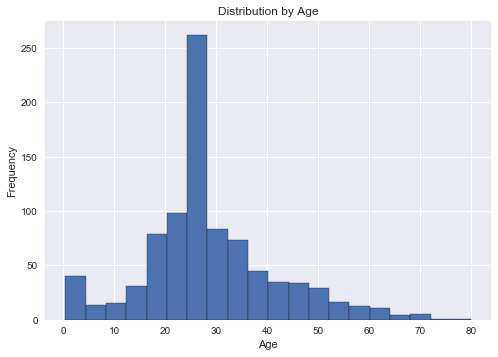

```python
plt = titanic['Age'].hist(bins = 20,ec='black')
plt.set_title('Distribution by Age')
plt.set(xlabel = 'Age', ylabel='Frequency')
#From the graph we can't really say much about the survival rate by the age variable
```

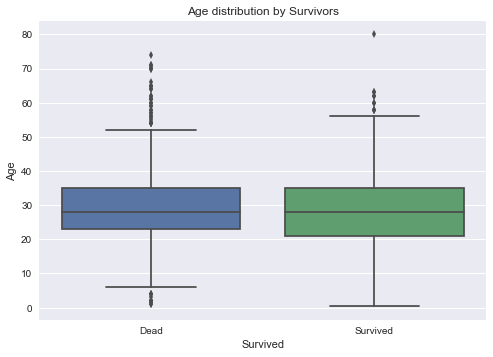

```python
bplt = sns.boxplot(data = titanic, x ='Survived', y='Age')
bplt.set(title ='Age distribution by Survivors' ,xticklabels = ['Dead', 'Survived'])
```

### Age w.r.t Gender

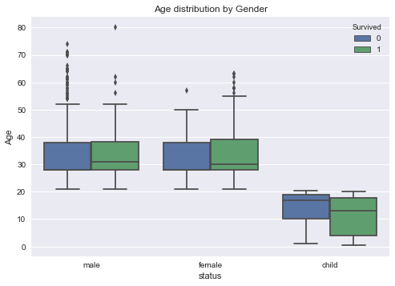

```python
bplt = sns.boxplot(data = titanic, x ='status', y='Age', hue='Survived')
bplt.set(title ='Age distribution by Gender')
```

This boxplot here shows that the mean age of the survivors in males and females is higher comapred to the deceased. It looks like younger kids had a higher chance of survival.

### Age w.r.t Pclass

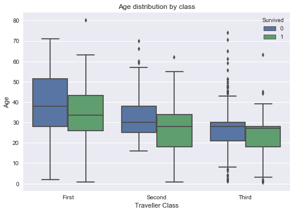

```python
bplt = sns.boxplot(data = titanic, x ='Pclass', y='Age', hue='Survived')
bplt.set(title ='Age distribution by class')
bplt.set(xlabel='Traveller Class')
bplt.set(xticklabels=['First','Second','Third'])
```

If we categorize the data by class, it seems like the survivability favors younger people, which can be because they were more quicker (and agile!) in saving themselves!

## Distribution by Embarked City

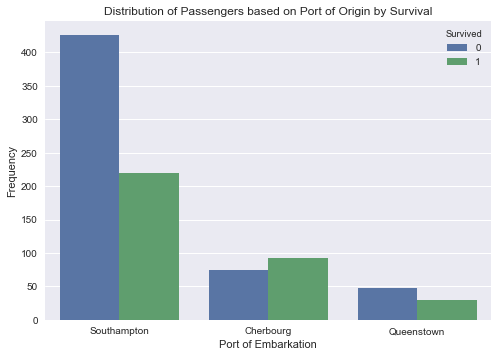

```python
eplt = sns.countplot(x = 'Embarked', hue='Survived',data = titanic)
eplt.set(xticklabels=['Southampton','Cherbourg','Queenstown'])
eplt.set(xlabel='Port of Embarkation', ylabel='Frequency')
eplt.set_title('Distribution of Passengers based on Port of Origin by Survival')
```

```python
cher_psgrs = titanic[titanic.Embarked == 'C']
queen_psgrs = titanic[titanic.Embarked == 'Q']
south_psgrs = titanic[titanic.Embarked == 'S']
```

```python
cher_psgrs.Survived.mean()
```

```
0.5535714285714286
```

```python
queen_psgrs.Survived.mean()
```

```
0.38961038961038963
```

```python
south_psgrs.Survived.mean()
```

```
0.3395348837209302
```

The ones who embarked the ship at Cherbourg have survival rate of 55% where as the ones who boarded at Queenstown have 39% & at Southampton have 34%

## Alone vs. Family

```python
titanic['SOLOFAM'] = titanic['SibSp'] + titanic['Parch']
```

```python
mask = titanic['SOLOFAM'] > 0
titanic.loc[mask,'SOLOFAM'] = 'Family'
titanic.loc[titanic['SOLOFAM'] == 0,'SOLOFAM'] = 'Alone'
```

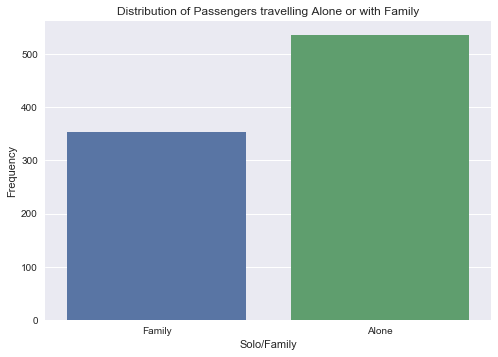

```python
plt = sns.countplot(x='SOLOFAM' , data=titanic)
plt.set(xlabel='Solo/Family',ylabel='Frequency')
plt.set_title('Distribution of Passengers travelling Alone or with Family')
```

Looks like the majority of the passengers were travelling solo. Lets look at their survival rate

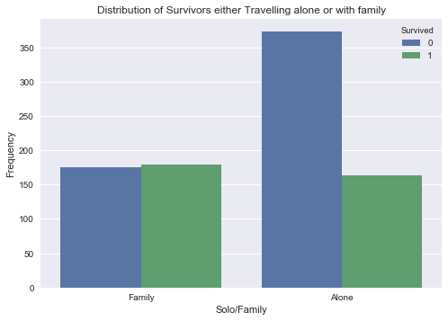

```python
plt = sns.countplot(x = 'SOLOFAM', hue='Survived',data = titanic)
plt.set(xlabel='Solo/Family',ylabel='Frequency')
plt.set_title('Distribution of Survivors either Travelling alone or with family')
```

```python
solo_psngrs = titanic[titanic.SOLOFAM == 'Alone']
fam_psngrs = titanic[titanic.SOLOFAM == 'Family']
```

```python
solo_psngrs.Survived.mean()
```

```
0.3041044776119403
```

```python
fam_psngrs.Survived.mean()
```

```
0.5056497175141242
```

The ones who were travelling with their families seemed to have higher survival rate (50 %) compared to the ones travelling alone(30%)

## Finalizing the important factors

```python
titanic.corr()
```

|  | PassengerId | Survived | Pclass | Age | SibSp | Parch | Fare |
| --- | --- | --- | --- | --- | --- | --- | --- |
| PassengerId | 1.000000 | -0.005375 | -0.035922 | 0.034800 | -0.057759 | -0.001872 | 0.012690 |
| Survived | -0.005375 | 1.000000 | -0.340458 | -0.063919 | -0.035760 | 0.081248 | 0.257456 |
| Pclass | -0.035922 | -0.340458 | 1.000000 | -0.338525 | 0.082370 | 0.017636 | -0.550143 |
| Age | 0.034800 | -0.063919 | -0.338525 | 1.000000 | -0.232874 | -0.172004 | 0.096678 |
| SibSp | -0.057759 | -0.035760 | 0.082370 | -0.232874 | 1.000000 | 0.414690 | 0.159707 |
| Parch | -0.001872 | 0.081248 | 0.017636 | -0.172004 | 0.414690 | 1.000000 | 0.216288 |
| Fare | 0.012690 | 0.257456 | -0.550143 | 0.096678 | 0.159707 | 0.216288 | 1.000000 |

## Conclusion

After playing around with the data, we come to see that the minimum age of the passengers was around 4 months and maximum age was 80 years old! These passengers were either travelling alone or together with atmost 6 family members.The given dataset had a lot of missing values, especially in columns Age, Cabin and Embarked. Since the column 'Cabin' will not tell us much about the survivability of the passengers, replacing those missing values wouldn't add much weight to the analysis. Thereby, I have decided to replace the missing values in column 'Age' by median and 'Embarked' by the most frequent item.

The dataset contains 890 rows of passenger details. Since we know that there were children on-board too, to find the distribution amongst these three categories i.e., Male, Female and Child, I have decided to use the 'age' variable for this. Given the fact that anyone above the age of 21 is an Adult. Using this condition, I have bifurcated the dataset into three groups. After doing so, there were 53% males, 26.5% - females and 20% - children. By looking at the plots of - 'Distribution of Passenger Demographics' we can draw conclusion regarding the survivability of each type. Males had a survival rate of 17% whereas females had 76% and children 45% of survival rate.

Now exploring the data by classes, we had three types of classes namely - First class a.k.a the luxury class, Second class and Third class. Looking at the survival rate of each class, the ones travelling in third class had a very bleak chance compared to the ones in First class. The upper class had a survival rate of 64%, middle class had around 47% and the lower class around 24%, which means that the person travelling in first class had almost three times more chance of survival compared to their third-class counterparts. Unfortunetly, third class had the most number of men and children travelling!

The Distribution by Age histogram shows that majority of the passengers are between the age group 20-30. Again from the barplot with Age and Gender, it shows that younger children had higher chances of survival. Interestingly, the port of origin shows some relation with the rate of survival. The ones who embarked the ship at Cherbourg have survival rate of 55% where as the ones who boarded at Queenstown have 39% & at Southampton have 34%. One more noticeable fact is that more than 500 passengers or so where travelling solo. Though the ones travelling with family had a survival rate of 50% whereas the ones going alone had only 30%. Maybe this was one of the reason why there were so many casualties!

In conclusion, I feel the variable list provided here isn't enough to draw a definite insight on the survivability of the passengers on Titanic. One important variable which I think should be present is - 'Crew Member or Not'. Since with this information we can differentiate between the true travellers and crew on-board. One of the main reason that led to such a huge loss of lives is because there weren't enough lifeboats. Linking this reason to the socio-economic factors back then, I think variables like physical demographics - 'Race' and 'Occupation' will help us understand the situation since probably there was some sort of discrimination on who gets onto the life-boats first etc.

## Resources

I have referred to the following sources for completing my analysis:

1. https://stackoverflow.com/python
2. https://elitedatascience.com/python-seaborn-tutorial
3. http://www.history.com/topics/titanic
4. https://www.encyclopedia-titanica.org/cabins.html